# HOMEWORK 3

Enes Ata Oruç

01/01/2021

### Libraries

```r
# execute necessary libraries
library(MLmetrics)
library(data.table)
library(dplyr)
library(tidyverse)
library(plotly)
library(scatterplot3d)
library(reshape)
library(lubridate)
library(glmnet)
library(caret)
```

### Importing and Manuplating Real Time Consumption data.

```r
# set working directory and read data
setwd("~/Desktop/IE 582 Files/HW3")
cons_data=fread("GercekZamanliTuketim.csv")
colnames(cons_data) = c('Date', 'Hour', 'Consumption')

# change variable types
# Date became date type
cons_data$Date <- dmy(cons_data$Date)

# Show only Hour number
cons_data$Hour <- hm(cons_data$Hour)
cons_data$Hour <- cons_data$Hour$hour
# Consumption became double type
cons_data$Consumption <- gsub(".", "", cons_data$Consumption, fixed = T)
cons_data$Consumption <- as.numeric(gsub(",", ".", cons_data$Consumption, fixed = T))

head(cons_data)
```

```
##          Date Hour Consumption
## 1: 2016-01-01    0    26277.24
## 2: 2016-01-01    1    24991.82
## 3: 2016-01-01    2    23532.61
## 4: 2016-01-01    3    22464.78
## 5: 2016-01-01    4    22002.91
## 6: 2016-01-01    5    21957.08
```

```r
# Every day should have unique hours. There should be no dublicates. Let's check it.
sum(duplicated(cons_data[,1:2]))
```

```
## [1] 1
```

```r
# we saw that there is a dublicated value in our data. Now let's detect which one
cons_data[which(duplicated(cons_data)),]
```

```
##          Date Hour Consumption
## 1: 2016-03-27    4    24776.94
```

```r
# We saw that there is a dublicate value in date 27.03.2016 because of the government's time policy.
# So, values for 27.03.2016 will be shown as NA

is.na(cons_data$Consumption) <- cons_data$Date == "2016-03-27"
```

### TASK 1: Navie Approach

In this task I will be predicting with consumption amount with 2-days period (lag_48) and 7-days period(lag_168). Than I will be calculating MAPE values in order to determine which approach is better.

```r
# Whole data with Lag columns added
# pred_date created. This will be used as whole data for predictions until a new data is needed.
pred_data <- cons_data %>% arrange(Date,Hour) %>%
  mutate(lag_48 = lag(Consumption, 48)) %>%
  mutate(lag_168 = lag(Consumption, 168))

#Test Set
test_cons_data <- pred_data[pred_data$Date >= "2020-11-01",]

#MAPE Calculations for Test Set
mape_test_value48 <- MAPE(test_cons_data$lag_48, test_cons_data$Consumption)
mape_test_value168 <- MAPE(test_cons_data$lag_168, test_cons_data$Consumption)
mape_test_value48
```

```
## [1] 0.08060315
```

```r
mape_test_value168
```

```
## [1] 0.03449188
```

So we see that 2 day lag (lag_48) approach gives 0.08060315 MAPE. 7 day lag (lag_168) approach gives 0.03449188 MAPE. This shows us using weekly seasonality is much more meaningful than 2 days seasonality for predicting next electric consumption values.

#### TASK 2: Linear Regression Approach

Another approach for a forecasting is treating lag consumptions as features and In this section I will be building a linear regression model. First, let’s start with creating Train set without NA’s and then build LR model and train the Test set. After the Linear Regression approach MAPE will be calculated again.

```r
# Train Set without NA's
train_cons_data <- pred_data[pred_data$Date < "2020-11-01",]
train_cons_data <- na.omit(train_cons_data)

regression_cons_data = lm(Consumption ~ lag_168 + lag_48, data = train_cons_data)
summary(regression_cons_data)
```

```
##
## Call:
## lm(formula = Consumption ~ lag_168 + lag_48, data = train_cons_data)
##
## Residuals:
##      Min       1Q   Median       3Q      Max
## -17125.7   -984.3     -1.2   1015.7  16097.4
##
## Coefficients:
##              Estimate Std. Error t value Pr(>|t|)
## (Intercept) 1.570e+03  8.351e+01   18.80   <2e-16 ***
## lag_168     6.430e-01  3.094e-03  207.83   <2e-16 ***
## lag_48      3.091e-01  3.096e-03   99.82   <2e-16 ***
## ---
## Signif. codes:  0 '***' 0.001 '**' 0.01 '*' 0.05 '.' 0.1 ' ' 1
##
## Residual standard error: 2388 on 42141 degrees of freedom
## Multiple R-squared:  0.7757, Adjusted R-squared:  0.7757
## F-statistic: 7.288e+04 on 2 and 42141 DF,  p-value: < 2.2e-16
```

MAPE with LR. Training the Test Set.

```r
lr_predict=predict(regression_cons_data, newdata = test_cons_data)
MAPE_lr <- MAPE(lr_predict, test_cons_data$Consumption)
MAPE_lr
```

```
## [1] 0.04231015
```

MAPE Value for the linear regression (LR) approach didn’t give better solution than the naive lag168 approach. Becase MAPE value for LR is 0.04231015 which worse than 0.03449188 (lag168 MAPE value). So, using regression model is not good enough to make a prediction.

#### TASK 3: Hourly Seasonality

So far we treated every Hour like they have same coefficients but this might not the correct assumption since night time consumptions may be different. In this section I will remodel the problem with considering each hour seperately. For the hourly seasonality I will create a for loop for hours then calculate the MAPE again.

```r
hourly_MAPE <- data.frame(Hour = 0:23, MAPE = rep(NA, 24))
for(i in 0:23){
  seasonal_hour <- lm(Consumption ~ lag_48 + lag_168, data = train_cons_data[train_cons_data$Hour == i,])
  pred_hour <- predict(seasonal_hour, newdata = test_cons_data[test_cons_data$Hour == i,])
  hourly_MAPE$MAPE[i+1] <- MAPE(pred_hour, test_cons_data[test_cons_data$Hour == i,]$Consumption)
}
summary(hourly_MAPE$MAPE)
```

```
##    Min. 1st Qu.  Median    Mean 3rd Qu.    Max.
## 0.03151 0.03200 0.03590 0.04361 0.05643 0.06687
```

```r
hourly_MAPE[hourly_MAPE$MAPE < MAPE(test_cons_data$lag_168, test_cons_data$Consumption),]
```

```
##    Hour       MAPE
## 1     0 0.03263542
## 2     1 0.03283588
## 3     2 0.03418989
## 4     3 0.03202953
## 5     4 0.03182975
## 6     5 0.03189139
## 7     6 0.03150869
## 20   19 0.03436128
## 21   20 0.03165305
## 22   21 0.03167038
## 23   22 0.03167298
## 24   23 0.03387197
```

```r
m<-mean(hourly_MAPE$MAPE)
```

As a result of this approach,Mean MAPE value for the assumption is 0.04361 which is still not better then weekly assumption. So, there is still not much improvement. I said not much because there are actually some hours that gave better solutions. Early in the mornings and late hours are created a group. So, this assumption is kind of useful in that sense.

#### TASK 4 Alternative Way to Hourly Approach

An alternative approach assuming that all hourly consumption values of last week (same day) can be important in the prediction of the next day’s consumption. I have to pivot my data from long to wide format, dcast() casts the data from long to wide format. It is in “data.table” package and I will be using that.

There is some data manupilation steps for lasso calculation. I transformed some of the features into the matrix form. Used L1 penalty (lambda1se) in my regression models for each hour.

```r
# wide format for whole data
lag_48 = dcast(pred_data, Date~Hour, fun = mean, value.var = "lag_48", fill = 0)
lag_168 = dcast(pred_data, Date~Hour, fun = mean, value.var = "lag_168", fill = 0)
colnames(lag_48) = c("Date", paste("Lag_day2_hour", 0:23, sep = "_"))
colnames(lag_168) = c("Date", paste("lag_day7_hour", 0:23, sep = "_"))
wide_format = pred_data %>%
  left_join(lag_48) %>%
  left_join(lag_168)
wide_format <- wide_format[, !c("lag_48","lag_168")]
wide_format <- data.table(wide_format[, c(1, 2,4:51, 3)])
wide_format <- na.omit(wide_format)

# Test and Train sets in wide format
wide_test <- wide_format[wide_format$Date >= "2020-11-01",]
wide_train <- wide_format[wide_format$Date < "2020-11-01",]

# Change to matrix for lasso implementation
matrix_test <- as.matrix(wide_test %>% select(-Date))
matrix_train <- as.matrix(wide_train %>% select(-Date))

# hold features in different set
train_features <- matrix_train[, 2:49]

# lasso model calculation
lasso_model <- cv.glmnet(x=train_features, y=wide_train$Consumption)
lasso_model
```

```
##
## Call:  cv.glmnet(x = train_features, y = wide_train$Consumption)
##
## Measure: Mean-Squared Error
##
##     Lambda  Measure    SE Nonzero
## min  0.251 15151362 82733      46
## 1se  3.394 15227568 80266      28
```

```r
# hold lambda1se value for further calculation
lambda1se <- lasso_model$lambda.1se

# appyly lasso to each hour
lasso1se_hourly = data.table()

for (i in 0:23){
  X_train = wide_format[Hour == i & Date < '2020-11-01',]
  X_train = as.matrix(X_train[,3:50])
  y_train = as.matrix(wide_format[Hour == i & Date < '2020-11-01', Consumption])
  X_test = wide_format[Hour == i & Date >= '2020-11-01',]
  X_test = as.matrix(X_test[,3:50])
  y_test = as.matrix(wide_format[Hour == i & Date >= '2020-11-01', Consumption])
  lasso_hourly = glmnet(X_train,
                             y_train,
                             alpha = 1,
                             lambda = lambda1se)
  pred_lasso = predict(lasso_hourly, newx = X_test)
  MAPE_lasso = MAPE(pred_lasso, y_test)
  lasso1se_hourly = rbind(lasso1se_hourly, data.table(Hour = i, MAPE = MAPE_lasso))
}

lasso1se_hourly
```

```
##     Hour       MAPE
##  1:    0 0.01410245
##  2:    1 0.01485174
##  3:    2 0.01478380
##  4:    3 0.01331228
##  5:    4 0.01359924
##  6:    5 0.01368078
##  7:    6 0.01609430
##  8:    7 0.01785928
##  9:    8 0.02538903
## 10:    9 0.03623927
## 11:   10 0.04181125
## 12:   11 0.04400073
## 13:   12 0.04631192
## 14:   13 0.04475552
## 15:   14 0.04273574
## 16:   15 0.03819123
## 17:   16 0.02923898
## 18:   17 0.02042018
## 19:   18 0.01568109
## 20:   19 0.01529694
## 21:   20 0.01592891
## 22:   21 0.01616308
## 23:   22 0.01490392
## 24:   23 0.01728412
##     Hour       MAPE
```

```r
MAPE_lasso
```

```
## [1] 0.01728412
```

```r
## compare hourly predictions and naive appr.
lasso1se_hourly[lasso1se_hourly$MAPE < MAPE(test_cons_data$lag_168, test_cons_data$Consumption),]
```

```
##     Hour       MAPE
##  1:    0 0.01410245
##  2:    1 0.01485174
##  3:    2 0.01478380
##  4:    3 0.01331228
##  5:    4 0.01359924
##  6:    5 0.01368078
##  7:    6 0.01609430
##  8:    7 0.01785928
##  9:    8 0.02538903
## 10:   16 0.02923898
## 11:   17 0.02042018
## 12:   18 0.01568109
## 13:   19 0.01529694
## 14:   20 0.01592891
## 15:   21 0.01616308
## 16:   22 0.01490392
## 17:   23 0.01728412
```

When all the approaches are considered it can be seen that penalized regression models with L1 penalty performed the best predictions. All hours from 2 days and 7 days should be considered while making predictions. There is also a similarity between Task 4 and Task 3, some of the hours showed the same characteristics what I mean by this is early in the mornings and evening hours.

#### Task 6: Ploting

Task says: Compare the results drawing a boxplot of MAPE values for each approach on same plot.

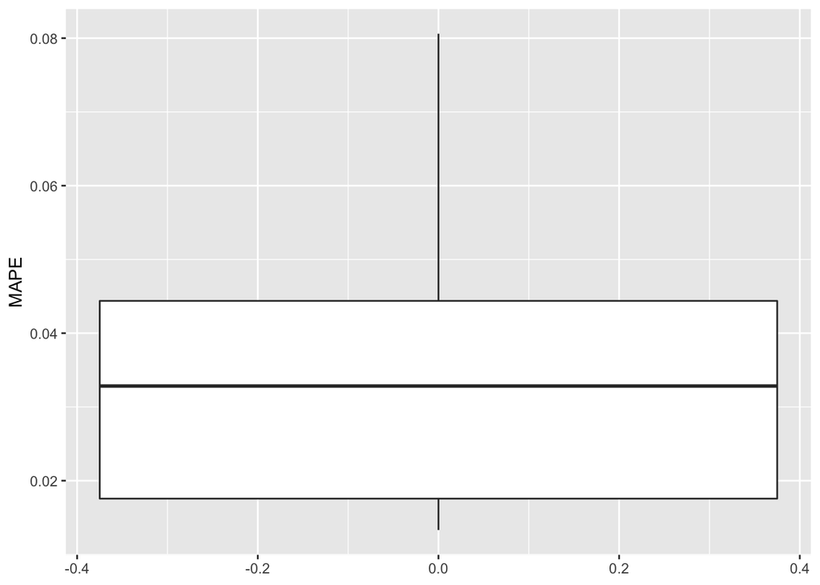

```r
# general boxplot for all assumptions
MAPE_plot = data.table(MAPE = c(mape_test_value48,mape_test_value168,MAPE_lr, hourly_MAPE$MAPE, lasso1se_hourly$MAPE), Model = c('lag 48', 'lag 168', 'Linear Regression', paste(0:23, 'Hourly_Regression', sep = '_'), paste(0:23, 'Lasso_1se', sep = '_')))

ggplot(data = MAPE_plot) +
  geom_boxplot(aes(y = MAPE))
```

```r
## best approaches with minimum error
order_MAPE_plot <- MAPE_plot[order(MAPE_plot$MAPE, decreasing = FALSE),]
head(order_MAPE_plot)
```

```
##          MAPE       Model
## 1: 0.01331228 3_Lasso_1se
## 2: 0.01359924 4_Lasso_1se
## 3: 0.01368078 5_Lasso_1se
## 4: 0.01410245 0_Lasso_1se
## 5: 0.01478380 2_Lasso_1se
## 6: 0.01485174 1_Lasso_1se
```

Top approaches belongs to lasso with L1 penalty.